# Lab 5 part 2

2022-10-19

```r
library(ggplot2)
```

```r
df <- read.csv("Diet_r.csv")
head(df)
```

```
##   Person gender Age Height pre.weight Diet weight6weeks
## 1     25     NA  41    171         60    2         60.0
## 2     26     NA  32    174        103    2        103.0
## 3      1      0  22    159         58    1         54.2
## 4      2      0  46    192         60    1         54.0
## 5      3      0  55    170         64    1         63.3
## 6      4      0  33    171         64    1         61.1
```

Firstly, let’s explore the data:

```r
summary(df)
```

```
##      Person          gender            Age            Height
##  Min.   : 1.00   Min.   :0.0000   Min.   :16.00   Min.   :141.0
##  1st Qu.:20.25   1st Qu.:0.0000   1st Qu.:32.25   1st Qu.:164.2
##  Median :39.50   Median :0.0000   Median :39.00   Median :169.5
##  Mean   :39.50   Mean   :0.4342   Mean   :39.15   Mean   :170.8
##  3rd Qu.:58.75   3rd Qu.:1.0000   3rd Qu.:46.75   3rd Qu.:174.8
##  Max.   :78.00   Max.   :1.0000   Max.   :60.00   Max.   :201.0
##                  NA's   :2
##    pre.weight          Diet        weight6weeks
##  Min.   : 58.00   Min.   :1.000   Min.   : 53.00
##  1st Qu.: 66.00   1st Qu.:1.000   1st Qu.: 61.85
##  Median : 72.00   Median :2.000   Median : 68.95
##  Mean   : 72.53   Mean   :2.038   Mean   : 68.68
##  3rd Qu.: 78.00   3rd Qu.:3.000   3rd Qu.: 73.83
##  Max.   :103.00   Max.   :3.000   Max.   :103.00
##
```

First, we can check for missing values:

```r
colSums(is.na(df))
```

```
##       Person       gender          Age       Height   pre.weight         Diet
##            0            2            0            0            0            0
## weight6weeks
##            0
```

There are 2 missing values regarding the gender. Since this categorical value is criical in order to proceed, we will just get rid of those two rows:

```r
df2 <- df[-c(1,2),]
```

```r
colSums(is.na(df2))
```

```
##       Person       gender          Age       Height   pre.weight         Diet
##            0            0            0            0            0            0
## weight6weeks
##            0
```

Let’s take a look at the distribution of weight before and after:

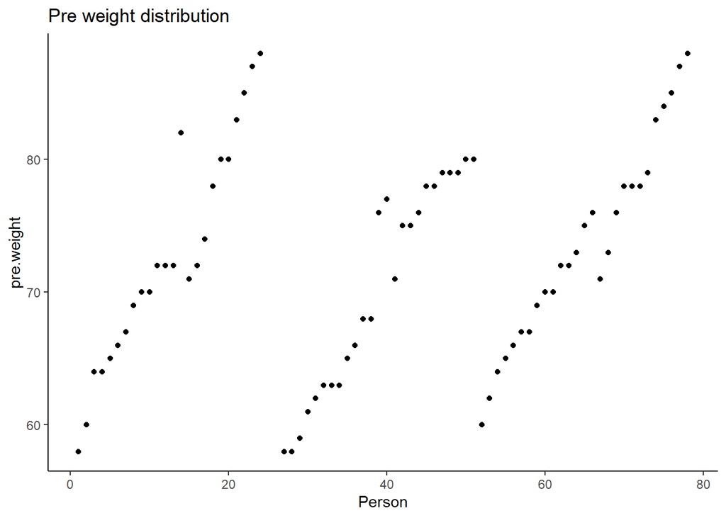

```r
# Person vs preweight
ggplot(data=df2, aes(x=Person, y=pre.weight)) + geom_point() + theme_classic() +
  ggtitle("Pre weight distribution")
```

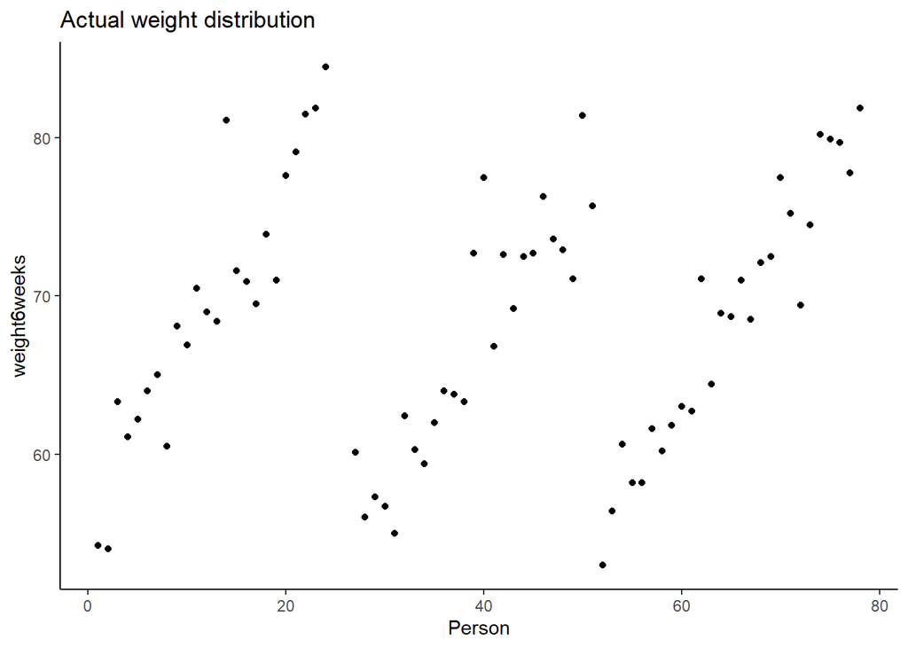

```r
# Person vs actual weight
ggplot(data=df2, aes(x=Person, y=weight6weeks)) + geom_point() + theme_classic() +
  ggtitle("Actual weight distribution")
```

We will dive into this later, but let’s see the distribution of the variables:

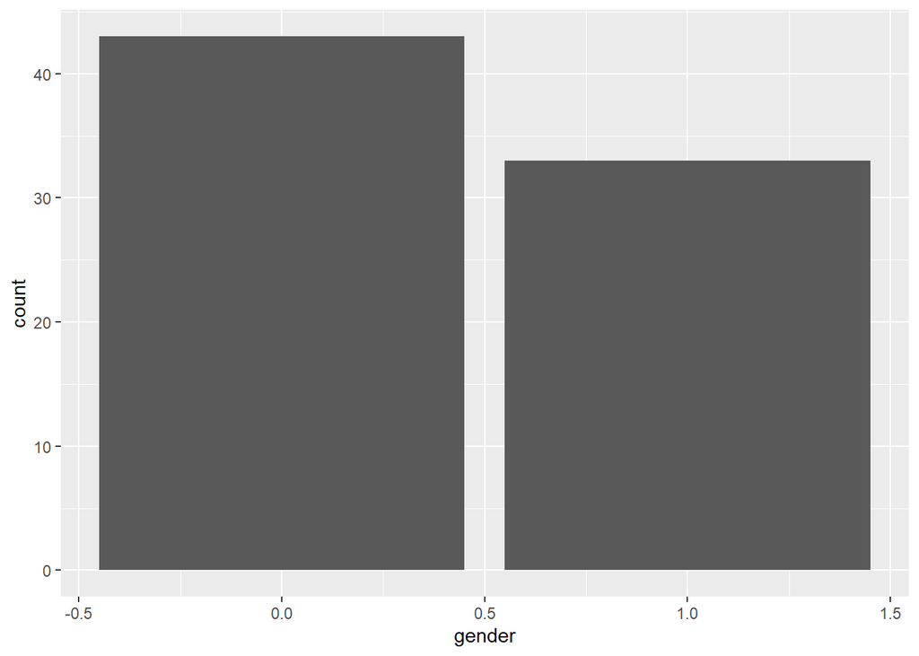

```r
# Gender
ggplot(df2, aes(x=gender)) +
  geom_bar()
```

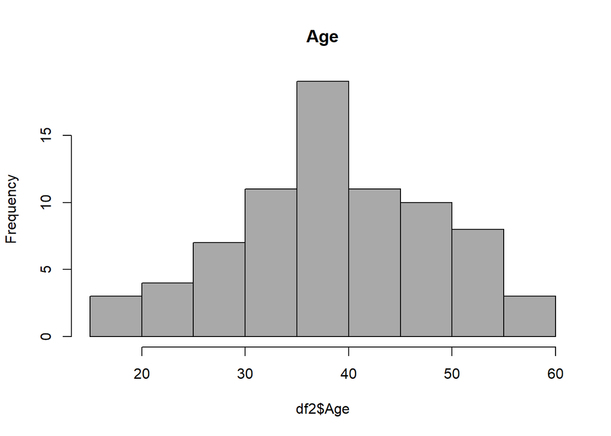

```r
# Age
hist(df2$Age,
     main="Age",
     col="darkgray",
     prob = FALSE
     )
```

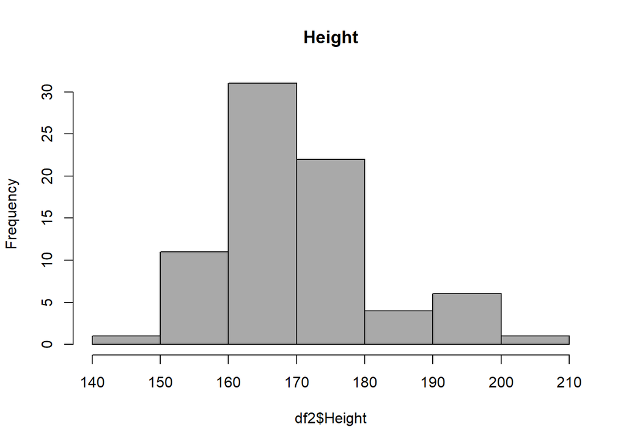

```r
# Height
hist(df2$Height,
     main="Height",
     col="darkgray",
     prob = FALSE
     )
```

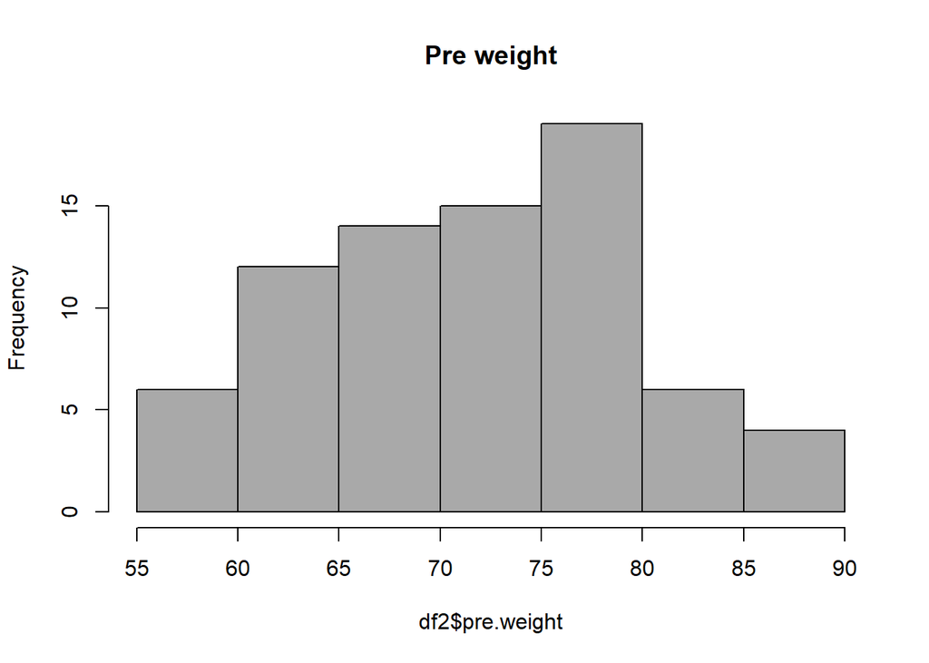

```r
# Pre weight
hist(df2$pre.weight,
     main="Pre weight",
     col="darkgray",
     prob = FALSE
     )
```

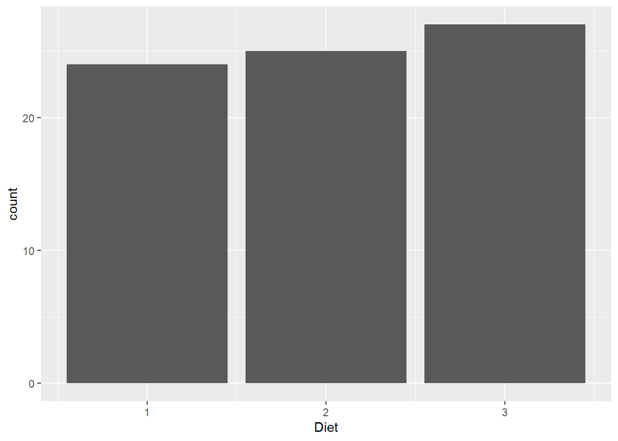

```r
# Diet
ggplot(df2, aes(x=Diet)) +
  geom_bar()
```

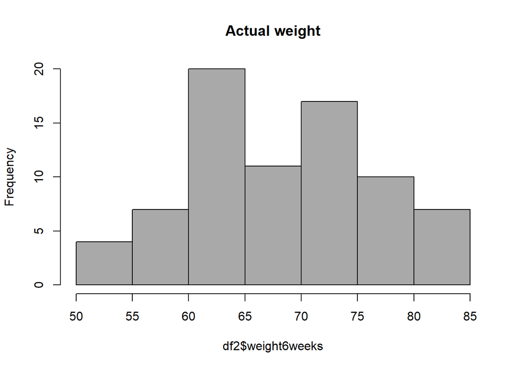

```r
# Weight after 6 weeks
hist(df2$weight6weeks,
     main="Actual weight",
     col="darkgray",
     prob = FALSE
     )
```

Now, we see how each variable is defined. We need to make changes, so categorical data must be set as factors:

```r
str(df2)
```

```
## 'data.frame':    76 obs. of  7 variables:
##  $ Person      : int  1 2 3 4 5 6 7 8 9 10 ...
##  $ gender      : int  0 0 0 0 0 0 0 0 0 0 ...
##  $ Age         : int  22 46 55 33 50 50 37 28 28 45 ...
##  $ Height      : int  159 192 170 171 170 201 174 176 165 165 ...
##  $ pre.weight  : int  58 60 64 64 65 66 67 69 70 70 ...
##  $ Diet        : int  1 1 1 1 1 1 1 1 1 1 ...
##  $ weight6weeks: num  54.2 54 63.3 61.1 62.2 64 65 60.5 68.1 66.9 ...
```

```r
df2$gender <- as.factor(df2$gender)
df2$Diet <- as.factor(df2$Diet)
```

Now we can test our first hypothesis: Is there a difference in weight before and after the diet?

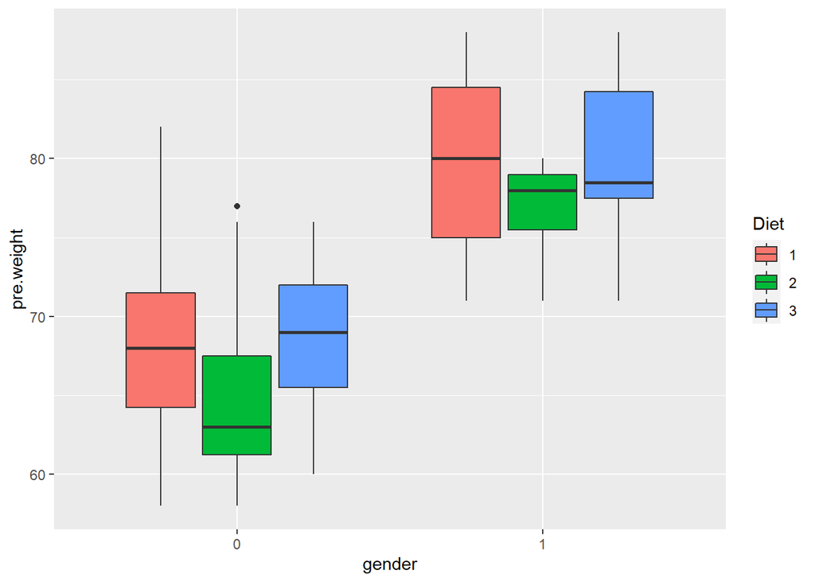

```r
# Weight by gender before diet
ggplot(data = df2, aes(x=gender, y=pre.weight)) + geom_boxplot(aes(fill=Diet))
```

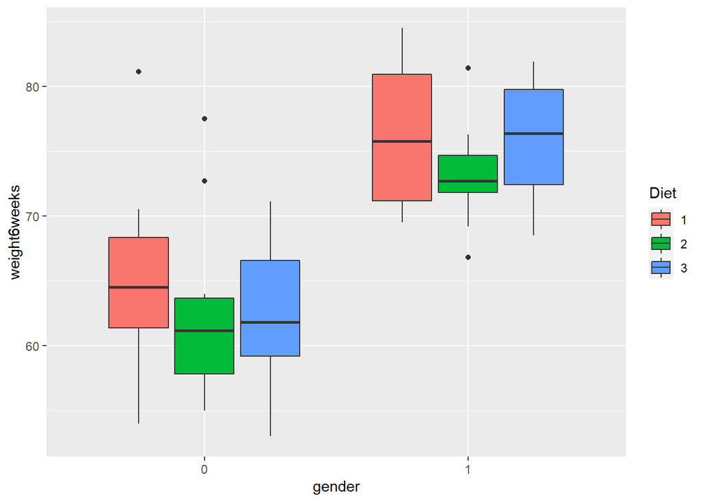

```r
# Weigth by gender aftyer diet
ggplot(data = df2, aes(x=gender, y=weight6weeks)) + geom_boxplot(aes(fill=Diet))
```

As seen, the weights in between diets looks similar, but we want to be more specific: We will do hypothesis testing with the weights. First we need to check for normality:

```r
shapiro.test(df2$pre.weight)
```

```
##
##  Shapiro-Wilk normality test
##
## data:  df2$pre.weight
## W = 0.97549, p-value = 0.1481
```

```r
shapiro.test(df2$weight6weeks)
```

```
##
##  Shapiro-Wilk normality test
##
## data:  df2$weight6weeks
## W = 0.9732, p-value = 0.1075
```

As seen, both p-values are high enough, so we cannot reject the null hypothesis, and therefore consider both variables to be normally distributed.

```r
t.test(df2$pre.weight,df2$weight6weeks, alternative = "two.sided")
```

```
##
##  Welch Two Sample t-test
##
## data:  df2$pre.weight and df2$weight6weeks
## t = 3.0342, df = 149.98, p-value = 0.002843
## alternative hypothesis: true difference in means is not equal to 0
## 95 percent confidence interval:
##  1.376358 6.515747
## sample estimates:
## mean of x mean of y
##  72.28947  68.34342
```

Doing a simple t-test, we can see that the p-value is < 0.05, so we can reject the null hypothesis, and therefore there is statistical difference in mean weights before and after dieting. But this analysis is really poor, as we are not taking into account the different categorical values.

Before starting, we can compute a new column containing the total weight-loss per person:

```r
df2$weightloss <- df2$pre.weight - df2$weight6weeks
```

Additionally, we can also add a column adding the bmi before and after dieting:

```r
df2$bmi.before <- df2$pre.weight/((df2$Height/100)^2)
df2$bmi.after <- df2$weight6weeks/((df2$Height/100)^2)
```

```r
summary(df2$weightloss)
```

```
##    Min. 1st Qu.  Median    Mean 3rd Qu.    Max.
##  -2.100   2.300   3.700   3.946   5.650   9.200
```

```r
summary(df2$bmi.before)
```

```
##    Min. 1st Qu.  Median    Mean 3rd Qu.    Max.
##   16.28   22.14   24.75   25.05   27.87   35.21
```

```r
summary(df2$bmi.after)
```

```
##    Min. 1st Qu.  Median    Mean 3rd Qu.    Max.
##   14.65   21.01   23.42   23.66   26.42   31.69
```

Now, we can use ANOVA and ANCOVA to model the relationship between the weight loss and the participants measurements/demographics. We can start with a simple analysis of variance between the weightoss and the type of diet applied:

```r
summary(aov(df2$weightloss~df2$Diet))
```

```
##             Df Sum Sq Mean Sq F value Pr(>F)
## df2$Diet     2   60.5  30.264   5.383 0.0066 **
## Residuals   73  410.4   5.622
## ---
## Signif. codes:  0 '***' 0.001 '**' 0.01 '*' 0.05 '.' 0.1 ' ' 1
```

This confirms that the diet types have significantly different weight-loss means.

```r
summary.lm(aov(df2$weightloss~df2$Diet))
```

```
##
## Call:
## aov(formula = df2$weightloss ~ df2$Diet)
##
## Residuals:
##     Min      1Q  Median      3Q     Max
## -5.3680 -1.4420  0.1759  1.6519  5.7000
##
## Coefficients:
##             Estimate Std. Error t value Pr(>|t|)
## (Intercept)   3.3000     0.4840   6.818 2.26e-09 ***
## df2$Diet2    -0.0320     0.6776  -0.047  0.96246
## df2$Diet3     1.8481     0.6652   2.778  0.00694 **
## ---
## Signif. codes:  0 '***' 0.001 '**' 0.01 '*' 0.05 '.' 0.1 ' ' 1
##
## Residual standard error: 2.371 on 73 degrees of freedom
## Multiple R-squared:  0.1285, Adjusted R-squared:  0.1047
## F-statistic: 5.383 on 2 and 73 DF,  p-value: 0.006596
```

As we can see, Diet 3 is significantly different from Diets 1 and 2 (with almost identical mean weight-loss), so we could say its the “most effective”. Again, as the p-value is <0.05, we can say that there is a statistical difference between groups.

```r
aggregate(weightloss~Diet, data=df2, FUN="mean")
```

```
##   Diet weightloss
## 1    1   3.300000
## 2    2   3.268000
## 3    3   5.148148
```

As seen, the mean weight-loss for Diet 3 is the highest.

We can also perform a more detailed study, and see what is the effect of gender in all this, using ANCOVA:

```r
ancova.wl<-lm(df2$weightloss~df2$Diet+df2$gender)
summary(ancova.wl)
```

```
##
## Call:
## lm(formula = df2$weightloss ~ df2$Diet + df2$gender)
##
## Residuals:
##     Min      1Q  Median      3Q     Max
## -5.3262 -1.4018  0.1218  1.6941  5.6445
##
## Coefficients:
##             Estimate Std. Error t value Pr(>|t|)
## (Intercept)  3.26038    0.53890   6.050  5.9e-08 ***
## df2$Diet2   -0.03422    0.68226  -0.050  0.96014
## df2$Diet3    1.84551    0.66982   2.755  0.00742 **
## df2$gender1  0.09508    0.55258   0.172  0.86387
## ---
## Signif. codes:  0 '***' 0.001 '**' 0.01 '*' 0.05 '.' 0.1 ' ' 1
##
## Residual standard error: 2.387 on 72 degrees of freedom
## Multiple R-squared:  0.1289, Adjusted R-squared:  0.09259
## F-statistic: 3.551 on 3 and 72 DF,  p-value: 0.01855
```

We can see from the results of the model that gender is not a significant coefficient, and the $r^2$ is very very low. This does not seem like a model that is more useful than the ANOVA using only the diet as the explanatory variable, where the $r^2$ is slightly higher (but almost the same really).